# 1. Matrix Classes

N. Frerebeau

2019-09-20

# 1 Definitions

The **tabula** package provides a set of S4 classes for archaeological data matrices that extend the basic `matrix` data type. These new classes represent different special types of matrix.

- Numeric matrix:
  - `CountMatrix` represents count data,
  - `FrequencyMatrix` represents relative frequency data.
  - `OccurrenceMatrix` represents a co-occurrence matrix.
  - `SimilarityMatrix` represents a (dis)similarity matrix.
- Logical matrix:
  - `IncidenceMatrix` represents presence/absence data.

*It assumes that you keep your data tidy*: each variable (taxon/type) must be saved in its own column and each observation (assemblage/sample/case) must be saved in its own row. Note that missing values are not allowed.

Methods for a variety of functions applied to objects from these classes provide tools for analysis, seriation and dating of archaeological assemblages. See `help(methods)` to list all available methods for these classes.

The internal structure of S4 classes implemented in **tabula** is depicted in the UML class diagram in the following figure.

[figure not shown]

UML class diagram of the S4 classes structure.

## 1.1 Numeric matrix

### 1.1.1 Count matrix

We denote the $m \times p$ count matrix by $A = \left[ a_{ij} \right] ~\forall i \in \left[ 1,m \right], j \in \left[ 1,p \right]$ with row and column sums:

$$\begin{align}
a_{i \cdot} = \sum_{j = 1}^{p} a_{ij} &&
a_{\cdot j} = \sum_{i = 1}^{m} a_{ij} &&
a_{\cdot \cdot} = \sum_{i = 1}^{m} \sum_{j = 1}^{p} a_{ij} &&
\forall a_{ij} \in \mathbb{N}
\end{align}$$

### 1.1.2 Frequency matrix

A frequency matrix represents relative abundances.

We denote the $m \times p$ frequency matrix by $B = \left[ b_{ij} \right] ~\forall i \in \left[ 1,m \right], j \in \left[ 1,p \right]$ with row and column sums:

$$\begin{align}
b_{i \cdot} = \sum_{j = 1}^{p} b_{ij} = 1 &&
b_{\cdot j} = \sum_{i = 1}^{m} b_{ij} &&
b_{\cdot \cdot} = \sum_{i = 1}^{m} \sum_{j = 1}^{p} b_{ij} &&
\forall b_{ij} \in \left[ 0,1 \right]
\end{align}$$

### 1.1.3 Co-occurrence matrix

A co-occurrence matrix is a symmetric matrix with zeros on its main diagonal, which works out how many times (expressed in percent) each pairs of taxa occur together in at least one sample.

The $p \times p$ co-occurrence matrix $D = \left[ d_{i,j} \right] ~\forall i,j \in \left[ 1,p \right]$ is defined over an $m \times p$ abundance matrix $A = \left[ a_{x,y} \right] ~\forall x \in \left[ 1,m \right], y \in \left[ 1,p \right]$ as:

$$d_{i,j} = \sum_{x = 1}^{m} \bigcap_{y = i}^{j} a_{xy}$$

with row and column sums:

$$\begin{align}
d_{i \cdot} = \sum_{j \geqslant i}^{p} d_{ij} &&
d_{\cdot j} = \sum_{i \leqslant j}^{p} d_{ij} &&
d_{\cdot \cdot} = \sum_{i = 1}^{p} \sum_{j \geqslant i}^{p} d_{ij} &&
\forall d_{ij} \in \mathbb{N}
\end{align}$$

## 1.2 Logical matrix

### 1.2.1 Incidence matrix

We denote the $m \times p$ incidence matrix by $C = \left[ c_{ij} \right] ~\forall i \in \left[ 1,m \right], j \in \left[ 1,p \right]$ with row and column sums:

$$\begin{align}
c_{i \cdot} = \sum_{j = 1}^{p} c_{ij} &&
c_{\cdot j} = \sum_{i = 1}^{m} c_{ij} &&
c_{\cdot \cdot} = \sum_{i = 1}^{m} \sum_{j = 1}^{p} c_{ij} &&
\forall c_{ij} \in \lbrace 0,1 \rbrace
\end{align}$$

# 2 Usage

```r
# Load packages
library(tabula)
library(magrittr)
```

## 2.1 Create

These new classes are of simple use, on the same way as the base `matrix`:

```r
set.seed(12345)
## Create a count data matrix
CountMatrix(data = sample(0:10, 100, TRUE),
            nrow = 10, ncol = 10)
```

```
#> 10 x 10 count data matrix:
#> (79c4a59f-2ac3-4f91-b755-e0b32b428d94)
#>    V1 V2 V3 V4 V5 V6 V7 V8 V9 V10
#> 1   2  6  2  3  9  7  9  3  3   6
#> 2   9  9  8  7  9 10  6  8  9   0
#> 3   7  0  3 10  2  3  6 10  3   2
#> 4   9  7  9  5  2  1  4  0  8   1
#> 5  10  6  6  8  2  2  6  2  1   4
#> 6   7  5  1  4  0  5  9  9  7   9
#> 7   1  0  3  2  9  2  7  6  9   5
#> 8   5  3 10  0  7  6  2  9  0   6
#> 9  10  7  8  0 10  9  4  9  8   8
#> 10  5  9  8  4  8  6 10  6  5   9
```

```r
## Create an incidence (presence/absence) matrix
## Numeric values are coerced to logical as by as.logical
IncidenceMatrix(data = sample(0:1, 100, TRUE),
                nrow = 10, ncol = 10)
```

```
#> 10 x 10 presence/absence data matrix:
#> (a5a9e049-cf64-4aff-8ef7-9773c4ffe7ff)
#>       V1    V2    V3    V4    V5    V6    V7    V8    V9   V10
#> 1   TRUE FALSE  TRUE FALSE FALSE FALSE  TRUE FALSE FALSE  TRUE
#> 2   TRUE  TRUE  TRUE FALSE  TRUE FALSE FALSE FALSE FALSE FALSE
#> 3   TRUE  TRUE  TRUE FALSE  TRUE FALSE  TRUE FALSE  TRUE  TRUE
#> 4   TRUE FALSE  TRUE  TRUE FALSE  TRUE FALSE FALSE  TRUE  TRUE
#> 5  FALSE FALSE  TRUE FALSE  TRUE  TRUE FALSE FALSE  TRUE  TRUE
#> 6   TRUE  TRUE  TRUE FALSE  TRUE FALSE FALSE FALSE FALSE  TRUE
#> 7   TRUE FALSE  TRUE FALSE FALSE  TRUE FALSE FALSE  TRUE  TRUE
#> 8  FALSE FALSE  TRUE  TRUE  TRUE FALSE  TRUE  TRUE FALSE FALSE
#> 9  FALSE  TRUE  TRUE  TRUE  TRUE  TRUE FALSE  TRUE FALSE FALSE
#> 10  TRUE FALSE FALSE FALSE FALSE  TRUE FALSE FALSE FALSE FALSE
```

Note that a `FrequencyMatrix` can only be created by coercion (see below).

## 2.2 Coerce

**tabula** uses coercing mechanisms (with validation methods) for data type conversions:

```r
## Create a count matrix
## Numeric values are coerced to integer and hence truncated towards zero
A1 <- CountMatrix(data = sample(0:10, 100, TRUE),
                  nrow = 10, ncol = 10)

## Coerce counts to frequencies
B <- as_frequency(A1)

## Row sums are internally stored before coercing to a frequency matrix
## (use totals() to get these values)
## This allows to restore the source data
A2 <- as_count(B)
all(A1 == A2)
```

```
#> [1] TRUE
```

```r
## Coerce to presence/absence
C <- as_incidence(A1)

## Coerce to a co-occurrence matrix
D <- as_occurrence(A1)
```

# 3 Visualization

Several types of graphs are available in **tabula** which uses **ggplot2** for plotting informations. This makes it easy to customize diagrams (e.g. using themes and scales).

## 3.1 Spot plot

Spot matrix allows direct examination of data (above/below some threshold):

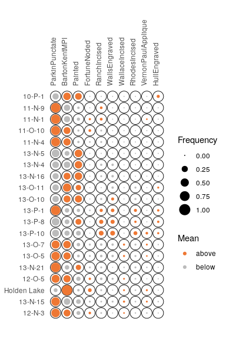

Spot plot

```r
## Plot frequencies with the column means as a threshold
mississippi %>%
  as_count() %>%
  plot_spot(threshold = mean) +
  ggplot2::labs(size = "Frequency", colour = "Mean") +
  khroma::scale_colour_vibrant()
```

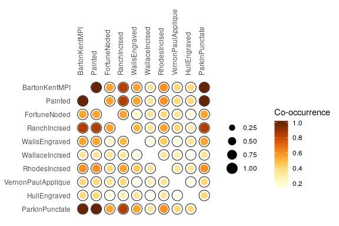

Spot plot of co-occurrence

```r
## Plot co-occurrence of types
## (i.e. how many times (percent) each pairs of taxa occur together
## in at least one sample.)
mississippi %>%
  as_occurrence() %>%
  plot_spot() +
  ggplot2::labs(size = "", colour = "Co-occurrence") +
  ggplot2::theme(legend.box = "horizontal") +
  khroma::scale_colour_YlOrBr()
```

## 3.2 Heatmap

Abundance matrix can be displayed as a heatmap of relative abundances (frequency), or as percentages of the independence value (in french, “pourcentages de valeur d’indépendance”, PVI).

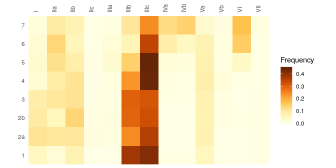

Heatmap

```r
boves %>%
  as_count() %>%
  plot_heatmap() +
  khroma::scale_fill_YlOrBr()
```

PVI is calculated for each cell as the percentage to the column theoretical independence value: PVI greater than $1$ represent positive deviations from the independence, whereas PVI smaller than $1$ represent negative deviations (Desachy 2004). The PVI matrix allows to explore deviations from independence (an intuitive graphical approach to $\chi^2$), in such a way that a high-contrast matrix has quite significant deviations, with a low risk of being due to randomness (Desachy 2004).

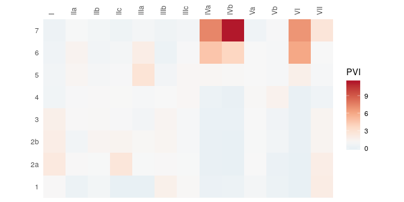

Matrigraphe

```r
## Reproduce B. Desachy's matrigraphe
boves %>%
  as_count() %>%
  plot_heatmap(PVI = TRUE) +
  khroma::scale_fill_BuRd(midpoint = 1)
```

## 3.3 Bar plot

Bertin (1977) or Ford (1962) (battleship curve) diagrams can also be plotted, with statistic threshold.

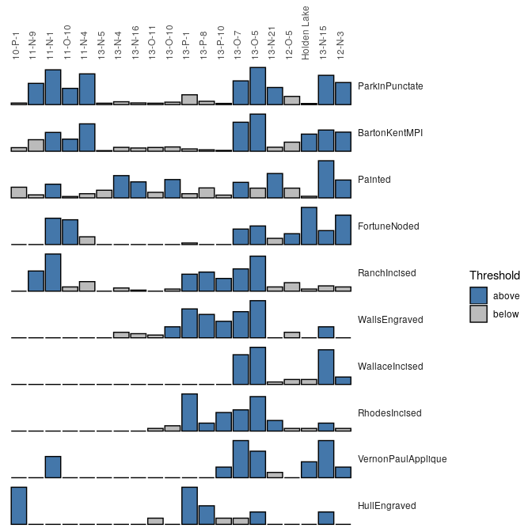

Bertin diagram

```r
mississippi %>%
  as_count() %>%
  plot_bertin(threshold = mean) +
  khroma::scale_fill_bright()
```

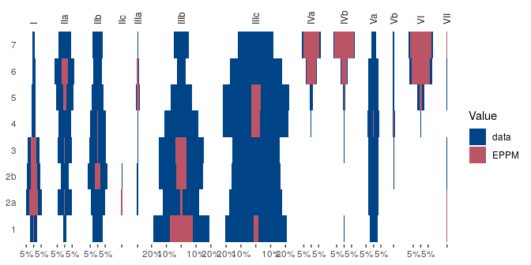

Ford diagram

```r
boves %>%
  as_count() %>%
  plot_ford(EPPM = TRUE) +
  khroma::scale_fill_contrast()
```

# References

Bertin, Jacques. 1977. *La graphique et le traitement graphique de l’information*. Nouvelle Bibliothèque Scientifique. Paris: Flammarion.

Desachy, Bruno. 2004. “Le sériographe EPPM : un outil informatisé de sériation graphique pour tableaux de comptages.” *Revue archéologique de Picardie* 3 (1): 39–56. https://doi.org/10.3406/pica.2004.2396.

Ford, J. A. 1962. *A Quantitative Method for Deriving Cultural Chronology*. Technical Manual 1. Washington, DC: Pan American Union.